# Exam 2016, solution

Niels Richard Hansen

April 10, 2016

# Problem 1

```r
wage <- read.table(
    "https://nielsrhansen.github.io/courses/regression2016/Exam/wage.txt",
    header = TRUE,
    colClasses = c("numeric", "numeric", "factor", "numeric", "numeric")
)
```

## Question 1.1

It is always a good idea to start with some explorative data analysis. In the exam situation it is not expected that you carry out an extensive exploration, but it may be worth noting that there are 341 unemployed among the 1125 respondents. The age distribution is a little atypical with few repondents in the middle age group. Finally, 876 (78%) have 0, 1 or 2 children living with them, but some have a lot more with 13 as the max. For the employed the max is 5.

We construct a new factor, `childrencut`, where respondents with 3 or more children at home are collapsed into one group. We also select the subset of the employed respondents for the analysis.

```r
wage$childrencut <- cut(wage$children, breaks = c(-1, 0, 1, 2, Inf),
                        labels = c("0", "1", "2", "3 or more"))
wage1 <- subset(wage, hours > 0)
```

In the additive, linear model we do not include hours. Even if it may be predictive of wage, it will not be useful for the final prediction in Question 1.4. The models presented here will be without hours included, but similar models including hours as a predictor could also be discussed.

```r
wagelm <- lm(wage ~ educ + age + childrencut, data = wage1)
```

We compare the fitted model with the data and a model fit, which includes the second order interactions between all three variables (this is the model fitted implicitly using `geom_smooth`, though the variance is not assume homogeneous, which is reflected in the confidence bands.)

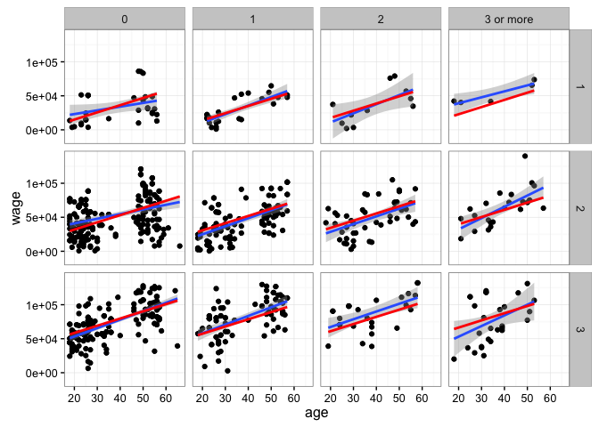

```r
wage1$pred <- predict(wagelm)
qplot(age, wage, data = wage1) +
  facet_grid(educ ~ childrencut) +
  geom_smooth(method = "lm") +
  geom_line(aes(y = pred), color = "red", size = 1)
```

What we observe is a general trend that wage increases with age and with educational level, but the number of children does not seem to be very predictive.

We can investigate this further using formal tests.

```r
drop1(wagelm, test = "F")
```

|  | Df | Sum of Sq | RSS | AIC | F value | Pr(>F) |
| --- | --- | --- | --- | --- | --- | --- |
|  | NA | NA | 426345622910 | 15783.46 | NA | NA |
| educ | 2 | 181806199973 | 608151822883 | 16057.92 | 165.667723 | 0.0000000 |
| age | 1 | 162937367460 | 589282990370 | 16035.21 | 296.947659 | 0.0000000 |
| childrencut | 3 | 4098801762 | 430444424672 | 15784.96 | 2.489974 | 0.0591461 |

These tests confirm that there is a statistically significant effect of education and age, but that the number of children is only borderline significant. Thus we cannot reject that the number of children is not predictive (at least not in the linear additive model).

## Question 1.2

We construct the standard diagnostic plots of residuals for the fitted model.

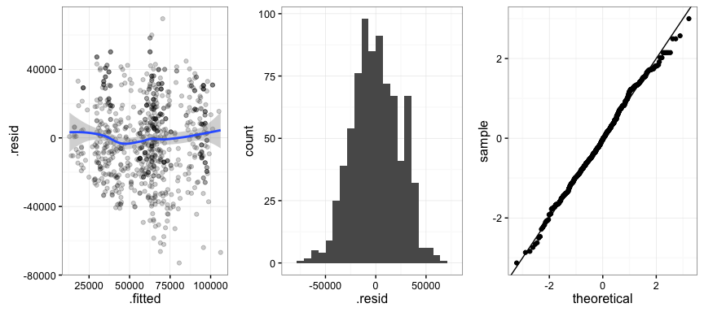

```r
wageDiag <- fortify(wagelm)
grid.arrange(
  qplot(.fitted, .resid, data = wageDiag, alpha = I(0.2)) +
    geom_smooth(),
  qplot(.resid, data = wageDiag, bins = 20),
  qplot(sample = .stdresid, data = wageDiag, geom = "qq") +
    geom_abline(),
  ncol = 3
)
```

There are no alarming deviations from the model assumptions detectable from any of the plots. The residual plot shows an almost constant variance across the different fitted values, and the smoother indicates that the linear model is not a bad fit, though it might be possible to improve it a little. The histogram and qq-plot indicate that the residual distribution is close to normal.

To further investigate we also plot the residuals against age.

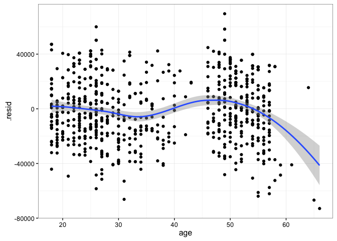

```r
qplot(age, .resid, data = wageDiag) + geom_smooth()
```

This plot shows that there may be some lack of fit for age. That is, the predictive effect of age is not adequately described by an affine function.

**N.B.** If hours is included into the model at this point, it is, of course also possible to further explore if this model fits the data. One will see a similar but much stronger deviation in the residual plots from linearity for age for the model that includes hours. It may be noteworthy that hours is also very predictive of wage. The linear model without hours has an adjusted $R^2$ of 0.45, whereas including hours increases the adjusted $R^2$ to 0.83.

## Question 1.3

We first extend the linear model by expanding age using natural cubic splines with 4 degrees of freedom. We construct a corresponding plot of residuals against age to see if this model corrects the lack of fit observed above.

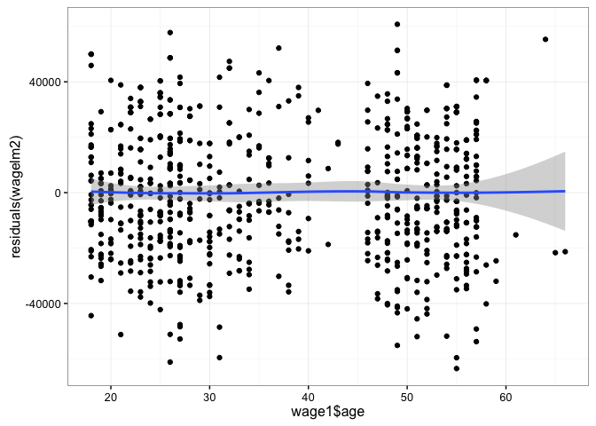

```r
wagelm2 <- lm(wage ~ educ + ns(age, df = 4) + childrencut,
              data = wage1)
qplot(wage1$age, residuals(wagelm2)) + geom_smooth()
```

We then include all first order interactions and compare the resulting three models using F-tests.

```r
wagelm3 <- lm(wage ~ (educ + ns(age, df = 4)+ childrencut)^2,
              data = wage1)
anova(wagelm, wagelm2, wagelm3)
```

| Res.Df | RSS | Df | Sum of Sq | F | Pr(>F) |
| --- | --- | --- | --- | --- | --- |
| 777 | 426345622910 | NA | NA | NA | NA |
| 774 | 398035588915 | 3 | 28310033995 | 19.146397 | 0.0000000 |
| 748 | 368666490264 | 26 | 29369098651 | 2.291845 | 0.0002874 |

As we can see from the tests, we can formally reject the linear, additive model, and the inclusion of the interactions is significant as well. Below are predictions made by the nonlinear models with and without interactions.

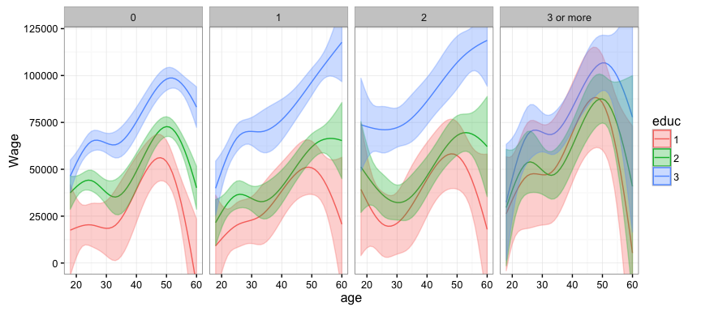

```r
predFrame <- expand.grid(childrencut = factor(levels(wage1$childrencut)),
                         age = seq(18, 60),
                         educ = factor(levels(wage1$educ)))
predWage <- cbind(
  predFrame,
  predict(wagelm3, newdata = predFrame,
          interval = "confidence")
  )

qplot(age, fit, data = predWage, geom = "line", color = educ) +
  geom_ribbon(aes(ymin = lwr, ymax = upr, fill = educ), alpha = 0.3) +
  facet_wrap(~ childrencut, ncol = 4) +
  ylab("Wage") +
  coord_cartesian(ylim = c(0, 120000))
```

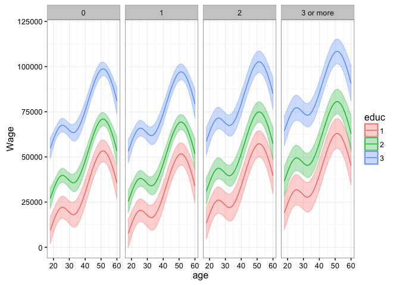

```r
predWage <- cbind(
  predFrame,
  predict(wagelm2, newdata = predFrame,
          interval = "confidence")
  )

qplot(age, fit, data = predWage, geom = "line", color = educ) +
  geom_ribbon(aes(ymin = lwr, ymax = upr, fill = educ), alpha = 0.3) +
  facet_wrap(~ childrencut, ncol = 4) +
  ylab("Wage") +
  coord_cartesian(ylim = c(0, 120000))
```

It is not completely clear, which model to prefer. It is possible to investigate the interactions in more detail, but this will not reveal a simpler interaction model that is clearly preferably. If we keep the full interaction model there is more uncertainty in the predictions. This is particularly so for respondents with 2 or 3 or more children. However, there does seem to be some clear differences in the predicted mean as a function of age for different combinations of education and number of children. For instance, those with a high education seem to have an increase of wage with age when they are (some) children, whereas for most other groups (and mostly pronounced for those with the lowest education), the wage levels out or decreases with age.

## Question 1.4

For the prediction we choose the full interaction model. We have constructed the model above so that it can give sensible predictions for the unemployed. Note that had we included hours as a predictor, we could not have used the model directly.

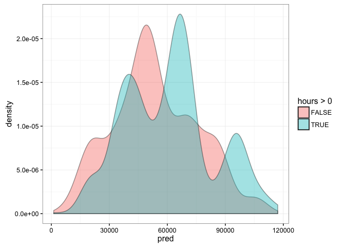

```r
wage$pred <- predict(wagelm3, newdata = wage)
qplot(pred, data = wage, fill = hours > 0, geom = "density", alpha = I(0.4))
```

In the comparison between the wage predictions made for the employed and the unemployed we see a clear difference. This reflects a difference in the distribution of the predictor variables in the two groups. There are e.g. relatively more with a high education that are employed than unemployed. The age distributions also differ.

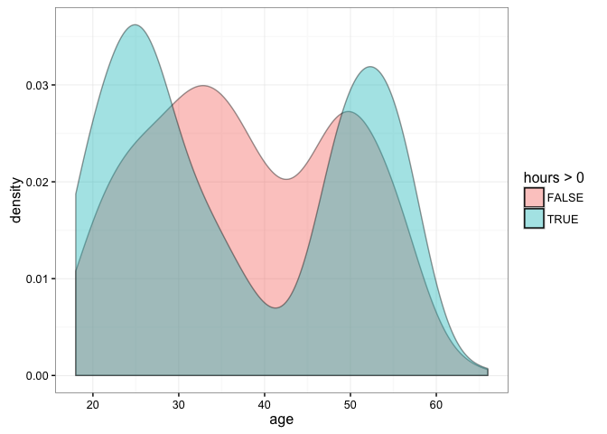

```r
qplot(age, data = wage, fill = hours > 0,
      geom = "density",
      alpha = I(0.4))
```

There is a larger group of unemployed in the middle age, whereas the age distribution for the employed is highly bimodal.

Hence the differences are explainable. But there are reasons why such predictions could be wrong. If the employed and unemployed groups differ in other ways than on the observed variables, then the predictions could be misleading. The unemployed might not have the same (necessary) skills or abilities, in which case they would likely get a lower wage. They might also be without jobs to take care of the children (the differences indicate that to some extent), in which case they might want to work less hours. Again, this could result in a lower wage. There could be other differences.

# Problem 2

```r
polychaeta <- read.table(
    "https://nielsrhansen.github.io/courses/regression2016/Exam/polychaeta.txt",
    header = TRUE,
    colClasses = c("factor", "numeric")
)
```

## Question 2.1

We compute the estimated mean values for each station using `lm` and extract the fitted means. This could also be done by simply computing the mean for each station using e.g. the `tapply` function.

```r
polylm <- lm(Count ~ Station - 1, data = polychaeta)
polychaeta$mu <- fitted(polylm)  ## Fitted mean values
mu <- with(polychaeta, tapply(mu, Station, mean))
## max(abs(mu - c(coef(polylm)))) ## Small

## Reordering the factor levels according to the
## fitted mean
ord <- order(coef(polylm))
polychaeta <- transform(
  polychaeta,
  Station = factor(
  as.character(Station),
  levels = levels(Station)[ord]
  )
)
mu <- mu[ord]
```

The reordering of the factor levels for `Station` was done to make the following plot more easy to read.

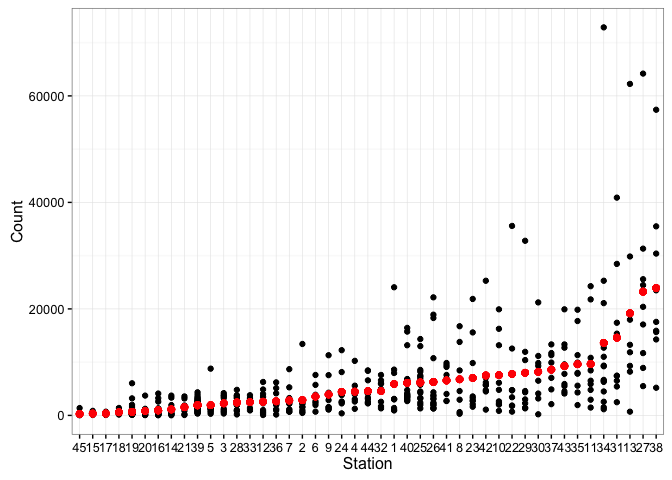

```r
qplot(Station, Count, data = polychaeta) +
  geom_point(aes(y = mu), col = "red", size = 2)
```

The plot clearly shows that the distribution of counts become more spread out the larger the station mean is. We can also construct a residual plot, and a plot of the absolute residuals, where we add the standard error estimate for the corresponding station.

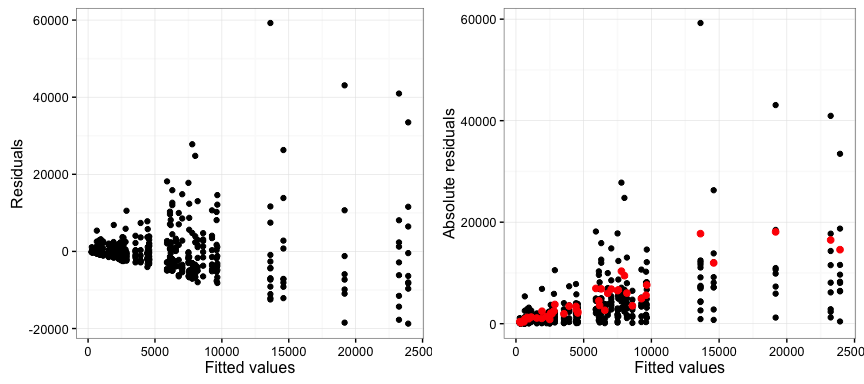

```r
## Estimate variances for each stations
sigmasq <- with(polychaeta, tapply((Count - mu)^2, Station, mean))
musig <- data.frame(mu = mu, sigma = sqrt(sigmasq))
## Residual plot
p1 <- qplot(mu, Count - mu, data = polychaeta) +
  ylab("Residuals") + xlab("Fitted values")
p2 <- qplot(mu, abs(Count - mu), data = polychaeta) +
  geom_point(aes(y = sigma),
             data = musig,
             color = "red",
             size = 2) +
  ylab("Absolute residuals") + xlab("Fitted values")
grid.arrange(p1, p2, ncol = 2)
```

These plot further corroborate that the variance cannot be assumed constant, and thus that $\mathcal{V}(\mu)$ cannot be assumed to be 1.

## Question 2.2

Since $E \varepsilon_i^2 = V \epsilon_i = \mathcal{V}(\mu_i) = \psi \mu_i^p$ under Taylor’s law, we get, by taking logarithms, that
$$\log(\xi_i) = \log(\psi \mu_i^p) = \log(\psi) + p \log(\mu_i).$$

If $\varepsilon_i \sim \mathcal{N}(0, \xi_i)$ then $\varepsilon_i^2$ is $\chi^2$-distributed with 1 degrees of freedom and scale parameter $\xi_i$. Hence the variance of $\varepsilon_i^2$ is
$$V \varepsilon_i^2 = 2 \xi_i^2.$$

In general,
$$\begin{aligned}
V \varepsilon_i^2 & = E \varepsilon_i^4 - (E \varepsilon_i^2)^2 \\
& = E \varepsilon_i^4 - \xi_i^2 \\
& = \xi_i^2 \left( \frac{E \varepsilon_i^4}{(V \epsilon_i)^2} - 1\right).
\end{aligned}$$
Since $\varepsilon_i$ has mean 0,
$$\kappa_i = \frac{E \varepsilon_i^4}{(V \epsilon_i)^2}$$
is the fourth standardized moment, thus it is the kurtosis. Note that for the normal distribution, kurtosis is 3, and the general formula for the variance of $\varepsilon_i^2$ reduces to $2 \xi_i^2$.

## Question 2.3

Based on the previous question the squared residuals, $\hat{\varepsilon}_i^2$, have approximately a mean-variance structure as a generalized linear model with log-link and quadratic variance function. Thus we can estimate $b$ and $\psi$ using a gamma response with the log-link and the logarithm of the fitted means as predictors.

```r
polyglm <- glm((Count - mu)^2 ~ log(mu),
               data = polychaeta,
               family = Gamma("log"))
coefficients(summary(polyglm))
```

|  | Estimate | Std. Error | t value | Pr(>\|t\|) |
| --- | --- | --- | --- | --- |
| (Intercept) | 1.520707 | 1.1378157 | 1.336514 | 0.1819953 |
| log(mu) | 1.792395 | 0.1398401 | 12.817457 | 0.0000000 |

The estimate of $b$ is around 1.8. (This concurs with typical estimates of the exponent between 1 and 2). We compare this estimated variance function to the data by using the figure from Question 2.1, where we add the fitted model.

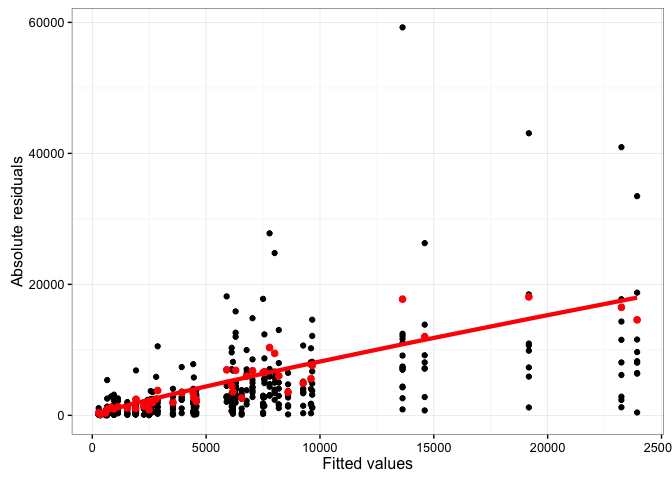

```r
musig$sighat <- sqrt(predict(polyglm, newdata = musig, type = "response"))
p2 + geom_line(aes(y = sighat), data = musig, color = "red", size = 1.5)
```

The model of the variance function appears to fit well with the data (the red points, which are the estimated standard deviations for each station, fall close to the fitted standard deviations).

To compute a confidence interval for $b$ we use the generalized linear model. We also compute the standard error for the estimate of $b$ for comparison with bootstrap computations below.

```r
confint(polyglm, 2) ## Profile confidence interval
```

```
##    2.5 %   97.5 %
## 1.532755 2.045041
```

```r
confint.default(polyglm, 2) ## Standard confidence interval
```

|  | 2.5 % | 97.5 % |
| --- | --- | --- |
| log(mu) | 1.518313 | 2.066476 |

```r
coef(summary(polyglm))[2, 2] ## Standard error
```

```
## [1] 0.1398401
```

Several comments are necessary. First, the above confidence interval does not account for the fact that the station means were estimated, and thus that the model was fitted using squared residuals and not the actual errors. Thus there is a model misspecification. We could work out moments of the residuals instead, but we will still need to regress on the fitted means and not the true means. Second, the kurtosis may depend on $\xi_i$ (though it does not for the normal error model), in which case the quadratic variance function is misspecified.

**The above comments are sufficient for a satisfactory answer of the question.** There are, however, a few options that could be pursued, if one wants to investigate the quality of the confidence interval above.

If the variance function is misspecified, we could use nonparametric bootstrapping.

```r
B <- 200
n <- nrow(polychaeta)
bhat <- numeric(B)
for(b in 1:B) {
  i <- sample(n, n, replace = TRUE)
  bootdata <- polychaeta[i, ]
  bootGlm <- glm((Count - mu)^2 ~ log(mu),
               data = bootdata,
               family = Gamma("log"))
  bhat[b] <- coefficients(bootGlm)[2]
}
```

We can then compute the standard error estimate based on bootstrapping, and the corresponding standard 95% confidence interval for $b$.

```r
se <- sd(bhat)
se
```

```
## [1] 0.1513984
```

```r
coef(polyglm)[2] + c(-1, 1) * 1.96 * se
```

```
## [1] 1.495654 2.089136
```

This gives a slightly wider confidence interval. Note, however, that this bootstrap implementation does still not account for the uncertainty associated with the estimation of the station means. If one tries to include that in the bootstrap, then the nonparametric bootstrap will produce *smaller* confidence intervals. This is counter intuitive, and I believe it is an example where the nonparametric bootstrap does not work adequately. But this will require more thought.

# Problem 3

The first code here was used to generate the summary statistics. Some will be used for the last two questions.

```r
## Code for simulation and MLE computation used to generate the
## statistics given in the exam.

## Distribution function
pgom <- function(t, eta, gam)
  1 - exp(-eta * (exp(gam * t) - 1))

## Quatile function
qgom <- function(q, eta, gam)
  (log(-log(1 - q) / eta + 1)) / gam

## Simulation function
rgom <- function(n, eta, gam)
  qgom(runif(n), eta, gam)
```

```r
## Parameters used for the simulation
n <- 50
eta <- 0.01
gam <- 0.1
lambda <- 0.01
set.seed(0504)
Tstar <- rgom(n, eta, gam)
C <- rexp(n, lambda)
e <- as.numeric(Tstar <= C)
T <- pmin(Tstar, C)
```

```r
## Computing statistics
nu <- sum(e)
t = sum(T)
s = sum(e * T)

## Negative log-likelihood and gradient
negl <- function(par, T, e) {
  n <- length(T)
  nu <- sum(e)
  t = sum(T)
  s = sum(e * T)
  eta <- par[1]
  gam <- par[2]
  -(log(eta * gam) * nu + gam * s + eta * (n - sum(exp(gam * T))))
}

grnegl <- function(par, T, e) {
  n <- length(T)
  nu <- sum(e)
  t = sum(T)
  s = sum(e * T)
  eta <- par[1]
  gam <- par[2]
  - c(nu/eta + n - sum(exp(gam * T)),
      nu/gam + s - eta * sum(T * exp(gam * T)))
}

## Optimization
tmp <- optim(c(eta, gam), negl, gr = grnegl,
             method = "L-BFGS-B", T = T, e = e,
             lower = 1e-10, hessian = TRUE)

## More statistics
etahat <- tmp$par[1]
gamhat <- tmp$par[2]
sexp = sum(exp(gamhat * T))
stexp = sum(T^2 * exp(gamhat * T))
data.frame(n, nu, t, s, gamhat, sexp, stexp)
```

| n | nu | t | s | gamhat | sexp | stexp |
| --- | --- | --- | --- | --- | --- | --- |
| 50 | 32 | 1637.006 | 1384.324 | 0.0938979 | 3396.416 | 9949983 |

## Question 3.1

The cumulative hazard function is given as
$$\Lambda(t) = - \log S(t) = \eta (e^{\gamma t} - 1)$$
and the hazard function is therefore
$$\lambda(t) = \Lambda'(t) = \eta \gamma e^{\gamma t}.$$

The likelihood is by (10.2) given as
$$L(\eta, \gamma) = \prod_{i=1}^n (\eta \gamma)^{e_i} e^{\gamma e_i T_i} \exp(- \eta (e^{\gamma T_i} - 1)),$$
thus the log-likelihood is
$$\begin{aligned}
\ell(\eta, \gamma) & = \sum_{i=1}^n e_i \log(\eta \gamma) + e_i \gamma T_i - \eta (e^{\gamma T_i} - 1) \\
& = \log(\eta \gamma) \left(\sum_{i=1}^n e_i\right) + \gamma \left(\sum_{i=1}^n e_i T_i\right)
- \eta \sum_{i=1}^n (e^{\gamma T_i} - 1) \\
& = \log(\eta \gamma) n_u + \gamma s + \eta \left( n - \sum_{i=1}^n e^{\gamma T_i} \right).
\end{aligned}$$

The log-likelihood is differentiable with derivative
$$\begin{aligned}
D \ell(\eta, \gamma) & = \left( \frac{n_u}{\eta} + n - \sum_{i=1}^n e^{\gamma T_i},
\frac{n_u}{\gamma} + s - \eta \sum_{i=1}^n T_i e^{\gamma T_i} \right).
\end{aligned}$$
If the MLE exists in the open set $(0,\infty)^2$ it must satisfy $D \ell(\eta, \gamma) = 0$, which is seen to be equivalent to the two stated equations for the MLE (this is the score equation).

## Question 3.2

The negative second derivative of $\ell$ is found to be
$$\begin{aligned}
- D^2 \ell(\eta, \gamma) & = \left(
\begin{array}{cc}
\frac{n_u}{\eta^2} & \sum_{i=1}^n T_i e^{\gamma T_i} \\
\sum_{i=1}^n T_i e^{\gamma T_i} & \frac{n_u}{\gamma^2} + \eta \sum_{i=1}^n T_i^2 e^{\gamma T_i}
\end{array}
\right).
\end{aligned}$$

Due to the score equation for the MLE, $(\hat{\eta}, \hat{\gamma})$, it holds that
$$\sum_{i=1}^n T_i e^{\hat{\gamma} T_i} = \frac{n_u}{\hat{\eta} \hat{\gamma}} + \frac{s}{\hat{\eta}},$$
hence the observed Fisher information equals
$$\begin{aligned}
\mathcal{J}^{\mathrm{obs}} = - D^2 \ell(\hat{\eta}, \hat{\gamma}) & = \left(
\begin{array}{cc}
\frac{n_u}{\hat{\eta}^2} & \frac{n_u}{\hat{\eta}\hat{\gamma}} + \frac{s}{\hat{\eta}} \\
\frac{n_u}{\hat{\eta} \hat{\gamma}} + \frac{s}{\hat{\eta}} & \frac{n_u}{\hat{\gamma}^2} + \hat{\eta} \sum_{i=1}^n T_i^2 e^{\hat{\gamma} T_i} \end{array}
\right).
\end{aligned}$$

Using the proof of Lemma 9.6 (or the standard formula, using the determinant, for inversion of a $2 \times 2$ matrix) and the comments after the proof the approximate quadratic profile-log-likelihood function is computed as
$$h(\gamma) = \left(\mathcal{J}^{\mathrm{obs}}_{22} - \frac{(\mathcal{J}^{\mathrm{obs}}_{12})^2}{\mathcal{J}^{\mathrm{obs}}_{11}}\right) (\gamma - \hat{\gamma})^2.$$
From the expression above for the Fisher information we find that
$$\begin{aligned}
\mathcal{J}^{\mathrm{obs}}_{22} - \frac{(\mathcal{J}^{\mathrm{obs}}_{12})^2}{\mathcal{J}^{\mathrm{obs}}_{11}}
& = \frac{n_u}{\hat{\gamma}^2} + \hat{\eta} \sum_{i=1}^n T_i^2 e^{\hat{\gamma} T_i} -
\frac{\hat{\eta}^2}{n_u} \left(\frac{n_u}{\hat{\eta}\hat{\gamma}} + \frac{s}{\hat{\eta}}\right)^2 \\
& = \frac{n_u}{\hat{\gamma}^2} + \hat{\eta} \sum_{i=1}^n T_i^2 e^{\hat{\gamma} T_i} -
\frac{1}{n_u} \left(\frac{n_u}{\hat{\gamma}} + s\right)^2
\end{aligned}$$

An approximate likelihood interval can then be computed. Here using a standard cutoff from the $\chi^2$-distribution to give a nominal 95% coverage.

```r
n <- 50
nu <- 32
t <- 1637
s <- 1384
gamhat <- 0.09390
sexp <- 3396
stexp <- 9949983
etahat <- nu / (sexp - n)
J <- (nu / gamhat^2 + etahat * stexp - (s + nu / gamhat)^2 / nu)
gamint <- gamhat + c(-1, 0, 1) * 1.96 * sqrt(1 / J)
names(gamint) <- c("lower", "gamhat", "upper")
gamint
```

```
##      lower     gamhat      upper
## 0.06821276 0.09390000 0.11958724
```

For illustration, we plot the quadratic approximation together with the profile log-likelihood (which can only be computed here because I have the full data set!).

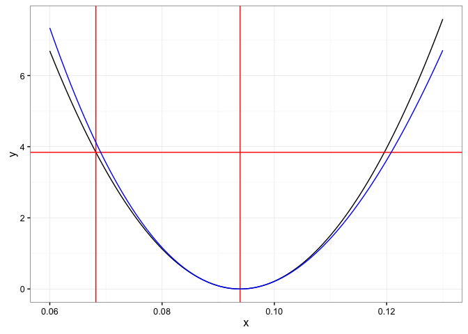

```r
x <- seq(0.06, 0.13, length.out = 400)
y <- J * (x - gamhat)^2
profl <- Vectorize(function(gam)
  2 * (negl( c(nu / (sum(exp(gam * T)) - n), gam), T, e) -
                negl(c(etahat, gamhat),T, e)))
yprof <- profl(x)

qplot(x, y, geom = "line") +
  geom_hline(yintercept = 3.84, color = "red") +
  geom_vline(xintercept = gamint[1], color = "red") +
  geom_vline(xintercept = gamint[2], color = "red") +
  geom_line(aes(y = yprof), color = "blue")
```

## Question 3.3

We use the implementation of the distribution function and the simulation functions above. Note that the simulation is based on the inverse distribution function (the quantile function). One could, alternatively, use exponentially distributed random variables and transform them using the inverse cumulative hazard function.

The Kaplan-Meier estimator is computed and plotted using the `survfit` function, and the theoretical survival function for the parameters estimated above is added.

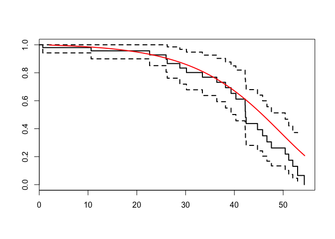

```r
lambdahat <- (n - nu) / t
Tstar <- rgom(n, etahat, gamhat)
C <- rexp(n, lambdahat)
Tsim <- pmin(Tstar, C)
esim <- as.numeric(Tstar <= C)
plot(survfit(Surv(Tsim, esim) ~ 1), mark.time = FALSE, lwd = 2)
curve(1 - pgom(x, etahat, gamhat), col = "red", add = TRUE, lwd = 2)
```

## Question 3.4

We implement a straight forward bootstrap algorithm of the combinant using `optim` for computing the MLE. We take $B = 9999$ as the computations are relatively fast.

```r
B <- 9999 ## Bootstrapping is cheap
comb <- numeric(B)
for(b in 1:B) {
  Tstar <- rgom(n, etahat, gamhat)
  C <- rexp(n, lambdahat)
  Tsim <- pmin(Tstar, C)
  esim <- as.numeric(Tstar <= C)
  nu <- sum(esim)
  t = sum(Tsim)
  s = sum(esim * Tsim)
  ## Optimizing
  tmp <- optim(c(eta, gam), negl, gr = grnegl,
               method = "L-BFGS-B", T = Tsim, e = esim,
               lower = 1e-10)
  etahatsim <- tmp$par[1]
  gamhatsim <- tmp$par[2]
  sexp = sum(exp(gamhatsim * Tsim))
  stexp = sum(Tsim^2 * exp(gamhatsim * Tsim))
  J <- (nu / gamhatsim^2 + etahatsim * stexp - (s + nu / gamhatsim)^2 / nu)
  comb[b] <- J * (gamhat - gamhatsim)^2
}
```

We compare some of the quantiles for the bootstrapped combinant with the quantiles for the theoretical $\chi^2$-approximation.

```r
qemp <- quantile(comb, c(0.9, 0.95, 0.975))
qtheo <- qchisq(c(0.9, 0.95, 0.975), 1)
cbind(qemp, qtheo)
```

|  | qemp | qtheo |
| --- | --- | --- |
| 90% | 2.720765 | 2.705544 |
| 95% | 3.807288 | 3.841459 |
| 97.5% | 4.804573 | 5.023886 |

We compare the two distributions in greater detail by a histogram and a qq-plot.

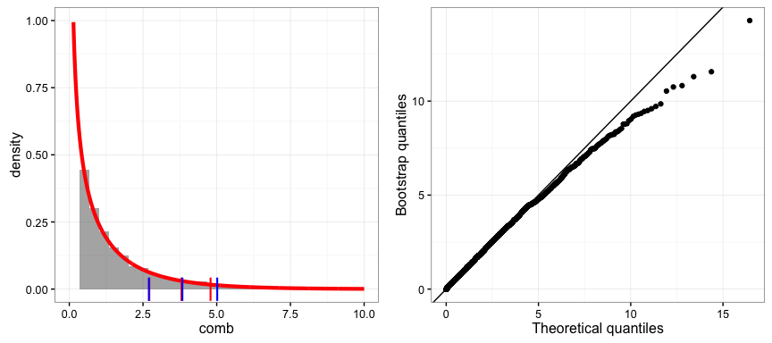

```r
x <- seq(0, 10, 0.01)
grid.arrange(
qplot(comb, ..density.., geom = "histogram", bins = 30, alpha = I(0.5)) +
  geom_line(aes(x, dchisq(x, 1)), color = "red", size = 1.5) +
  ylim(c(0, 1)) + xlim(c(0,10)) +
  geom_point(aes(qemp, y = c(0, 0, 0)), color = "red", shape = "|", size = 7) +
  geom_point(aes(qtheo, y = c(0, 0, 0)), color = "blue", shape = "|", size = 7),
qplot(qchisq(ppoints(B), 1), sort(comb)) +
  geom_abline(slope = 1, intercept = 0) +
  xlab("Theoretical quantiles") +
  ylab("Bootstrap quantiles"),
ncol = 2
)
```

We see that the $\chi^2$-approximation is fine except for the tail, where it decays a little slower than the bootstrapped distribution. However, for the quantiles of interest for (standard) statistical inference, the $\chi^2$-approximation is similar to the bootstrapped distribution.